# Airbnb New User Bookings

## Where Will a New Guest Book Their First Travel Experience?

## A Kaggle Challenge

We are given a list of users along with their demographics, web session records, and some summary statistics. We would like to create different algorithms to gain insights to predict which country a new user’s first booking destination will be.

There are 12 possible outcomes of the destination country: ‘US’, ‘FR’, ‘CA’, ‘GB’, ‘ES’, ‘IT’, ‘PT’, ‘NL’,‘DE’, ‘AU’, ‘NDF’ (no destination found), and ‘other’.All the users in this dataset are from the USA.

The training and test sets are split by dates. In the test set, we will predict all the new users with first activities after 7/1/2014 (note: this is updated on 12/5/15 when the competition restarted). In the sessions dataset, the data only dates back to 1/1/2014, while the users dataset dates back to 2010.

```
Loading data...

Dataframe dimensions:
[1] 213451     16
```

## Exploratory Data Analysis

### Airbnb subscriptions over time

Let’s see how has been the evolution of the creation of Airbnb accounts, we will see that is a popular service that has sustained an increase in the number of subscriptions over time.

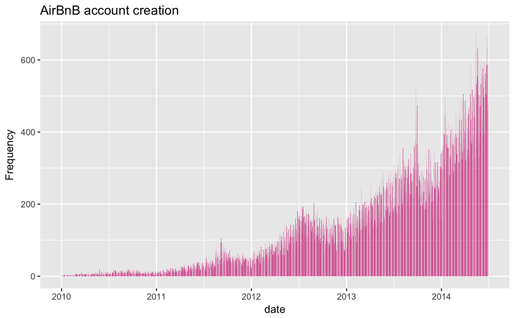

### Signup Channels

We can see the segmentation of subcriptors based on the method trhough which they sign up in Airbnb: basic, facebook, google:

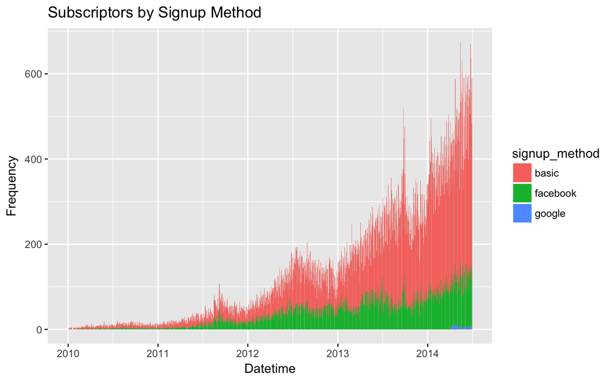

We are interested to know if people from a particular signup channel has a relation with bookings. For this, we run a Logistict regression to see the change in odds of this signup methods in booking.

Although, there is less than .2% which sign up in AirBnb through Google, those users, increase the odds to book in Airbnb more than 3 times. We can have a special attention to those users and try to look for causal variables that can explain counfanding factors.

```
             (Intercept) df$signup_methodfacebook   df$signup_methodgoogle
                1.350417                 1.130032                 3.262651
```

### Subscribers behavior to book

We want to see if older subscribers tend to book in shorter time? Does the maturity of the digital platform give newer subscriptors more trust?

As we can see in the following plots, subscribers in average tend to book in longer periods

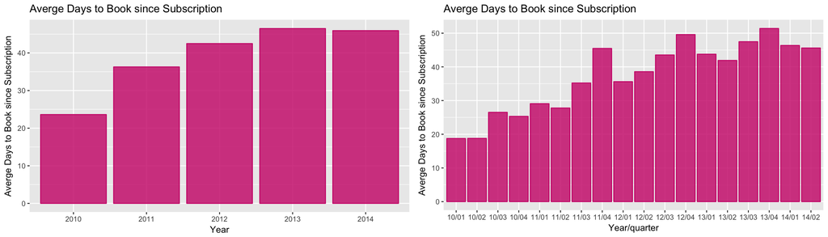

## Seasonality

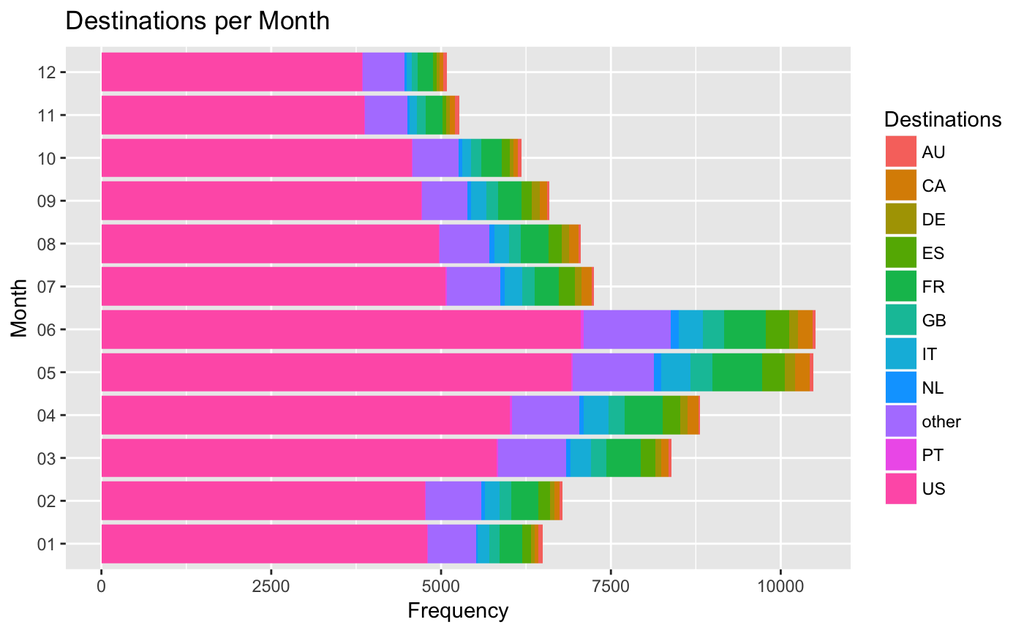